# INFO370-PS04

Marco

2024-07-17

```r
library(tidyverse)
library(caret)
library(dplyr)
library(margins)
```

# 1

## 1.1 Replicate the model from PS03 question 1.2.3.

```r
abnb <- read_delim("../data/airbnb-bangkok-listings.csv.bz2",
                   col_select = c("bedrooms", "price", "accommodates", "room_type"))
airbnb <- abnb %>%
  mutate(price = as.numeric(gsub("[$,]", "", price))) %>%
  filter(!is.na(bedrooms))
airbnb <- airbnb %>%
  mutate(
     bedrooms = cut(bedrooms,
                   breaks = c(1, 2, 3, 4, Inf),
                   labels = c("1", "2", "3", "4+"),
                   right = FALSE),
    accommodates = cut(accommodates,
                   breaks = c(1, 2, 3, 4, Inf),
                   labels = c("1", "2", "3", "4 and more"),
                   right = FALSE)
  )
m_log <- lm(log(price) ~ bedrooms + room_type + accommodates, data = airbnb)
```

## 1.2 use the model to predict (log) price for each listing

```r
yhat <- predict(m_log)
```

## 1.3 Compute RMSE

```r
rmse <- sqrt(mean((log(airbnb$price) - yhat)^2))
rmse
```

```
## [1] 0.7179466
```

The root mean squared error is 0.7179466

## 1.4 use your model to predict the price for full 2BR apartment

```r
full2b4a <- airbnb %>%
  filter(bedrooms == "2" & accommodates == "4 and more" & room_type == "Entire home/apt")
yhat <- predict(m_log, full2b4a)
mean(yhat)
```

```
## [1] 7.722903
```

The mean predicted log price of the model is 7.722903

## 1.5 Compute the average log price for all these listings in data in this group

```r
mean(log(full2b4a$price))
```

```
## [1] 7.716905
```

The average price for all listing in 2BR apartment that accomodates 4 people is 7.716905 which is pretty close to predicted result of 7.722903

# 2 Heart attack: predictive modeling

## 2.1 Inferential modeling

### 2.1.1

```r
ha <- read_delim("../data/heart.csv.bz2")
dim(ha)
```

```
## [1] 303  14
```

```r
summary(ha)
```

```
##       age             sex               cp            trtbps
##  Min.   :29.00   Min.   :0.0000   Min.   :0.000   Min.   : 94.0
##  1st Qu.:47.50   1st Qu.:0.0000   1st Qu.:0.000   1st Qu.:120.0
##  Median :55.00   Median :1.0000   Median :1.000   Median :130.0
##  Mean   :54.37   Mean   :0.6832   Mean   :0.967   Mean   :131.6
##  3rd Qu.:61.00   3rd Qu.:1.0000   3rd Qu.:2.000   3rd Qu.:140.0
##  Max.   :77.00   Max.   :1.0000   Max.   :3.000   Max.   :200.0
##       chol            fbs            restecg          thalachh
##  Min.   :126.0   Min.   :0.0000   Min.   :0.0000   Min.   : 71.0
##  1st Qu.:211.0   1st Qu.:0.0000   1st Qu.:0.0000   1st Qu.:133.5
##  Median :240.0   Median :0.0000   Median :1.0000   Median :153.0
##  Mean   :246.3   Mean   :0.1485   Mean   :0.5281   Mean   :149.6
##  3rd Qu.:274.5   3rd Qu.:0.0000   3rd Qu.:1.0000   3rd Qu.:166.0
##  Max.   :564.0   Max.   :1.0000   Max.   :2.0000   Max.   :202.0
##       exng           oldpeak          slp             caa
##  Min.   :0.0000   Min.   :0.00   Min.   :0.000   Min.   :0.0000
##  1st Qu.:0.0000   1st Qu.:0.00   1st Qu.:1.000   1st Qu.:0.0000
##  Median :0.0000   Median :0.80   Median :1.000   Median :0.0000
##  Mean   :0.3267   Mean   :1.04   Mean   :1.399   Mean   :0.7294
##  3rd Qu.:1.0000   3rd Qu.:1.60   3rd Qu.:2.000   3rd Qu.:1.0000
##  Max.   :1.0000   Max.   :6.20   Max.   :2.000   Max.   :4.0000
##      thall           output
##  Min.   :0.000   Min.   :0.0000
##  1st Qu.:2.000   1st Qu.:0.0000
##  Median :2.000   Median :1.0000
##  Mean   :2.314   Mean   :0.5446
##  3rd Qu.:3.000   3rd Qu.:1.0000
##  Max.   :3.000   Max.   :1.0000
```

```r
sum(is.na(ha))
```

```
## [1] 0
```

```r
sample_n(ha, 5)
```

```
## # A tibble: 5 × 14
##     age   sex    cp trtbps  chol   fbs restecg thalachh  exng oldpeak   slp
##   <dbl> <dbl> <dbl>  <dbl> <dbl> <dbl>   <dbl>    <dbl> <dbl>   <dbl> <dbl>
## 1    56     1     1    130   221     0       0      163     0     0       2
## 2    67     0     0    106   223     0       1      142     0     0.3     2
## 3    39     0     2     94   199     0       1      179     0     0       2
## 4    46     0     2    142   177     0       0      160     1     1.4     0
## 5    54     0     2    110   214     0       1      158     0     1.6     1
## # ℹ 3 more variables: caa <dbl>, thall <dbl>, output <dbl>
```

There’s 303 rows and 14 columns. There are no missing values in this data and all variables are in acceptable range.

### 2.1.2 Explain categorical varibales

`Sex` is categorical since people are either male or female.

`CP` is categorical since it represents different type of chest pain. This is important for us to change since it has 4 categories.

`fbs` is categorical since it indicates either true or false.

`restecg` is categorical since it indicates different type of resting electrocardiographic results. This is also important for us to change since it has 3 different categories.

`exng` is categorical since it indicate either yes or no

`output` is categorical since it indicates whether a person have heart attact.

### 2.1.3 Convert those variables to categoricals

```r
ha <- ha %>%
  mutate(
    sex = factor(sex),
    cp = factor(cp),
    fbs = factor(fbs),
    restecg = factor(restecg),
    exng = factor(exng),
    output = factor(output)
  )
```

### 2.1.4 Construct a logistic regression model

```r
m <- glm(output ~ ., data = ha, family = binomial())
summary(margins(m))
```

```
##    factor     AME     SE       z      p   lower   upper
##       age -0.0004 0.0025 -0.1630 0.8705 -0.0054  0.0046
##       caa -0.0859 0.0189 -4.5330 0.0000 -0.1230 -0.0487
##      chol -0.0005 0.0004 -1.2847 0.1989 -0.0013  0.0003
##       cp1  0.1515 0.0714  2.1216 0.0339  0.0115  0.2915
##       cp2  0.2510 0.0557  4.5072 0.0000  0.1419  0.3602
##       cp3  0.2637 0.0712  3.7021 0.0002  0.1241  0.4033
##     exng1 -0.1078 0.0526 -2.0491 0.0405 -0.2109 -0.0047
##      fbs1 -0.0012 0.0586 -0.0206 0.9836 -0.1160  0.1136
##   oldpeak -0.0539 0.0232 -2.3217 0.0203 -0.0994 -0.0084
##  restecg1  0.0544 0.0396  1.3742 0.1694 -0.0232  0.1320
##  restecg2 -0.0392 0.2613 -0.1500 0.8808 -0.5513  0.4730
##      sex1 -0.1908 0.0470 -4.0552 0.0001 -0.2830 -0.0986
##       slp  0.0629 0.0381  1.6522 0.0985 -0.0117  0.1375
##  thalachh  0.0024 0.0011  2.1499 0.0316  0.0002  0.0046
##     thall -0.0965 0.0299 -3.2260 0.0013 -0.1551 -0.0379
##    trtbps -0.0019 0.0011 -1.7361 0.0825 -0.0041  0.0002
```

### 2.1.5 Interpret the results of age, sex, and exng.

The reference category for this model is female at age 0 without exercise induced angina.

The P value of `Sex1` is 0.0001 which is less than 0.05, therefore it is statistically significant.

The coefficient of `age` indicates that with other factors unchanged, a person who is one year older on average has a probability of 0.04 percent point less likely to get heart attact.

The p value of `age` is 0.8705 which is more than 0.05, therefore it is not statistically significant.

The coefficient of `exng` indicates that with other factors unchanged a person with exercise induced angina on average has a probability of 10.7 percent point less likely to get heart attact than a person without exercise induced angima.

The p value is 0.0405 which is less than 0.05, therefore it is statistically significant.

## 2.2 Predictive modeling with caret

### 2.2.1 convert your outcome variable (here output) to a categorical

```r
ha <- ha %>%
  mutate(output = factor(output))
```

### 2.2.2 Fit the model using the train() function.

```r
m <- train(output ~ . , data = ha, family = "binomial", method = "glm")
```

### 2.2.3 Predict the probability of having a heart attack

```r
prob <- predict(m, type = "prob")
print(prob[1:10, 2])
```

```
##  [1] 0.7180293 0.7197638 0.9690937 0.9288898 0.8063068 0.7465016 0.8606974
##  [8] 0.8677962 0.8296901 0.9385450
```

### 2.2.4 Predict the label (outcome)

```r
yhat <- predict(m)
head(yhat, 10)
```

```
##  [1] 1 1 1 1 1 1 1 1 1 1
## Levels: 0 1
```

### 2.2.5 Show that both methods give you the same results.

```r
table(yhat, prob[2] > 0.5)
```

```
##
## yhat FALSE TRUE
##    0   122    0
##    1     0  181
```

Both method gives me same result.

### 2.2.6 Display the confusion matrix.

```r
cm <- table(yhat, ha$output)
cm
```

```
##
## yhat   0   1
##    0 108  14
##    1  30 151
```

### 2.2.7 Compute and display precision and recall.

```r
cm_f <- confusionMatrix(yhat, ha$output,
                        positive = "1", mode = "prec_recall")
cm_f
```

```
## Confusion Matrix and Statistics
##
##           Reference
## Prediction   0   1
##          0 108  14
##          1  30 151
##
##                Accuracy : 0.8548
##                  95% CI : (0.81, 0.8925)
##     No Information Rate : 0.5446
##     P-Value [Acc > NIR] : < 2e-16
##
##                   Kappa : 0.7044
##
##  Mcnemar's Test P-Value : 0.02374
##
##               Precision : 0.8343
##                  Recall : 0.9152
##                      F1 : 0.8728
##              Prevalence : 0.5446
##          Detection Rate : 0.4983
##    Detection Prevalence : 0.5974
##       Balanced Accuracy : 0.8489
##
##        'Positive' Class : 1
##
```

```r
TN <- cm[1, 1]
FN <- cm[1, 2]
TP <- cm[2, 2]
FP <- cm[2, 1]
P <- TP/(TP+FP)
R <- TP/(TP+FN)
P
```

```
## [1] 0.8342541
```

```r
R
```

```
## [1] 0.9151515
```

```r
precision(yhat, ha$output, relevant = "1")
```

```
## [1] 0.8342541
```

```r
recall(yhat, ha$output, relevant = "1")
```

```
## [1] 0.9151515
```

### 2.2.8 which measure should we try to improve

We should try to improve recall, since we want to minimize false negative which is missing the detection of a heart attack.

### 2.2.9 How confident is the model in its predictions?

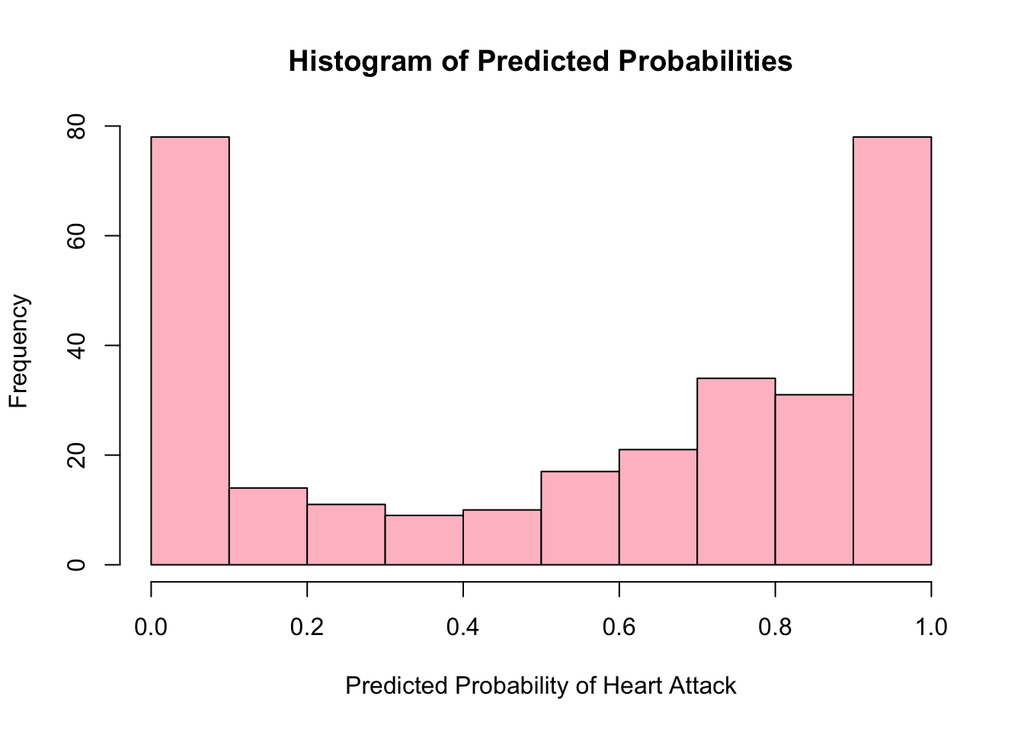

```r
hist(prob$'1', col= "pink", main = "Histogram of Predicted Probabilities", xlab = "Predicted Probability of Heart Attack")
```

The model is mostly confident since the values mostly appears around 0 and 1.

### 2.2.10 Now create another very simple model

```r
table(ha$output)
```

```
##
##   0   1
## 138 165
```

```r
yhat <- factor(rep("1", nrow(ha)), levels = levels(ha$output))
naive_m <- confusionMatrix(yhat, ha$output,
                           positive = "1", mode = "prec_recall")
naive_m
```

```
## Confusion Matrix and Statistics
##
##           Reference
## Prediction   0   1
##          0   0   0
##          1 138 165
##
##                Accuracy : 0.5446
##                  95% CI : (0.4866, 0.6016)
##     No Information Rate : 0.5446
##     P-Value [Acc > NIR] : 0.5237
##
##                   Kappa : 0
##
##  Mcnemar's Test P-Value : <2e-16
##
##               Precision : 0.5446
##                  Recall : 1.0000
##                      F1 : 0.7051
##              Prevalence : 0.5446
##          Detection Rate : 0.5446
##    Detection Prevalence : 1.0000
##       Balanced Accuracy : 0.5000
##
##        'Positive' Class : 1
##
```

```r
A <- (165)/(165 + 138)
P <- 165/(165+138)
R <- 165/165
A
```

```
## [1] 0.5445545
```

```r
P
```

```
## [1] 0.5445545
```

```r
R
```

```
## [1] 1
```

Having heart attack is more common, so I choose to use 1 for all values. \ The accuracy and precision is both 0.5445545 and the recall is 1.

### 2.2.11

The logistic regression model has significantly higher accuracy and precision, F1 score. Even its recall was not as high as the naive model, it predicts only the majority which is not useful in real world scenario.

# 3 Confusion matrix

## 3.1 What are the actual and what are the predicted values in this context?

The actual values are determined by manual review \ The predicted values are based on criminal codes.

## 3.2 Does the CM have actual values in rows, or predicted values in rows?

The CM has predicted values in rows and actual values in columns.

## 3.3 Does the CM have positive values first or negative values first?

The CM has positive values in first.

## 3.4 How many false positives and false negatives are reported?

There are 360 False negative and 0 False positives.

## 3.5 Display the CM using the convention

```r
TN <- 4953
TP <- 77
FP <- 0
FN <- 360


cm <- matrix(c(TN, FP, FN, TP), nrow = 2, byrow = TRUE)
cm
```

```
##      [,1] [,2]
## [1,] 4953    0
## [2,]  360   77
```

Actuals in rows and negative first

## 3.6 NPV, Se

NPV means negative predictive value which is the proportion of Predicted “no firearm related” that are actually “no firearm related” \

```r
4953 / 5390
```

```
## [1] 0.9189239
```

Se means sensitivity which is the proportion of actual firearm-related that are correctly identified by the model. \

```r
77/437
```

```
## [1] 0.1762014
```

```r
precision <- TP/(TP+FP)
recall <- TP/(TP+FN)
F1 <- 2*precision*recall/(recall+precision)
precision
```

```
## [1] 1
```

```r
recall
```

```
## [1] 0.1762014
```

```r
F1
```

```
## [1] 0.2996109
```

The precision is 1, the recall is 0.1762014, and the F-score is 0.2996109.

# 4 Overfitting and validation

## 4.1 Explore data

### 4.1.1 Load the data. Are there any missings?

```r
cancer <- read_delim("../data/wdbc.csv.bz2")
sum(is.na(cancer))
```

```
## [1] 0
```

```r
cancer <- cancer %>%
  select(-id) %>%
  mutate(diagnosis = factor(diagnosis, levels = c("B", "M")))
```

There are no missings in the data set.

### 4.1.2 Split your data into training and validation chunks

```r
set.seed(370)
it <- createDataPartition(cancer$diagnosis, p = 0.8, list = FALSE)
b0t <- cancer[it, ]
b0v <- cancer[-it, ]
```

### 4.1.3 How many cancer/non-cancer cases do we have in training data?

```r
table(b0t$diagnosis)
```

```
##
##   B   M
## 286 170
```

There are 170 cancer cases and 286 non-cancer cases in training data. Non-cancer cases are majority categories.

### 4.1.4 a naive model that assigns all results to the majority category.

Since Non cancer cases are majority, naive model would predict every cases non cancer. Which is B = 456, M = 0 \ Set have cancer to be positive and non cancer to be negative.

```r
TN <- 286
TP <- 0
FP <- 0
FN <- 170

cm <- matrix(c(TN, FP, FN, TP), nrow = 2, byrow = TRUE)
cm
```

```
##      [,1] [,2]
## [1,]  286    0
## [2,]  170    0
```

We have negative goes first and actuals in rows.

### 4.1.5 What is the accuracy, precision and recall of the naive model when computed on your validation

data?

```r
table(b0v$diagnosis)
```

```
##
##  B  M
## 71 42
```

```r
TN <- 71
TP <- 0
FP <- 0
FN <- 42
A <- (TP+TN)/(TN+TP+FN +FP)
P <- TP/(TP+FP)
R <- TP/(TP+FN)
A
```

```
## [1] 0.6283186
```

```r
P
```

```
## [1] NaN
```

```r
R
```

```
## [1] 0
```

### 4.1.6 which measure is the most appropriate

Recall should be the most critical measure htere since it indicates the model’s ability to correctly identify cancer cases. We want to minimize the the cancer cases we miss. We should also take care of overall combination since we can’t predict everyone to have cancer.

## 4.2 Three-feature model to predict cancer

### 4.2.1 use these three features to train a logistic regression model

```r
m <- train(
  diagnosis ~ texture.mean + concpoints.mean + symmetry.se , data = b0t,
  family = binomial, method = "glm"
)
```

### 4.2.2 Display the confusion matrix

```r
yhat <- predict(m, newdata = b0v)
confusionMatrix(yhat, b0v$diagnosis,
                positive = "M", mode = "prec_recall")
```

```
## Confusion Matrix and Statistics
##
##           Reference
## Prediction  B  M
##          B 67  6
##          M  4 36
##
##                Accuracy : 0.9115
##                  95% CI : (0.8433, 0.9567)
##     No Information Rate : 0.6283
##     P-Value [Acc > NIR] : 6.062e-12
##
##                   Kappa : 0.8087
##
##  Mcnemar's Test P-Value : 0.7518
##
##               Precision : 0.9000
##                  Recall : 0.8571
##                      F1 : 0.8780
##              Prevalence : 0.3717
##          Detection Rate : 0.3186
##    Detection Prevalence : 0.3540
##       Balanced Accuracy : 0.9004
##
##        'Positive' Class : M
##
```

### 4.2.3 How does the results look like, compared to the naive model from 4.1.5?

Accuracy, precision and recall are all higher than the naive model.

### 4.2.4 Now repeat this with 5 different sets of three features.

```r
m <- train(
  diagnosis ~ radius.mean + texture.mean + perimeter.mean , data = b0t,
  family = binomial, method = "glm"
)
yhat <- predict(m, newdata = b0v)
cm <- confusionMatrix(yhat, b0v$diagnosis,
                positive = "M", mode = "prec_recall")
cm$byClass["Recall"]
```

```
##    Recall
## 0.8333333
```

```r
m <- train(
  diagnosis ~ fracdim.mean + smoothness.mean + compactness.mean , data = b0t,
  family = binomial, method = "glm"
)
yhat <- predict(m, newdata = b0v)
cm <- confusionMatrix(yhat, b0v$diagnosis,
                positive = "M", mode = "prec_recall")
cm$byClass["Recall"]
```

```
##    Recall
## 0.8095238
```

```r
m <- train(
  diagnosis ~ fracdim.mean + radius.mean + perimeter.mean , data = b0t,
  family = binomial, method = "glm"
)
cm <- confusionMatrix(yhat, b0v$diagnosis,
                positive = "M", mode = "prec_recall")
cm$byClass["Recall"]
```

```
##    Recall
## 0.8095238
```

```r
m <- train(
  diagnosis ~ symmetry.worst + radius.mean + perimeter.mean , data = b0t,
  family = binomial, method = "glm"
)
yhat <- predict(m, newdata = b0v)
cm <- confusionMatrix(yhat, b0v$diagnosis,
                positive = "M", mode = "prec_recall")
cm$byClass["Recall"]
```

```
##    Recall
## 0.8571429
```

```r
m <- train(
  diagnosis ~ symmetry.worst + radius.mean + fracdim.mean , data = b0t,
  family = binomial, method = "glm"
)
yhat <- predict(m, newdata = b0v)
cm <- confusionMatrix(yhat, b0v$diagnosis,
                positive = "M", mode = "prec_recall")
cm$byClass["Recall"]
```

```
##    Recall
## 0.8571429
```

## 4.3 How does model performance depend on the number of features?

### 4.3.1 Write a loop over all predictors

```r
features <- colnames(cancer)[-1]
columns <- character(0)
Rv <- numeric()
Rt <- numeric()
for(n in features) {
  columns <- c(columns, n)
  formula <- as.formula(paste("diagnosis ~", paste(columns, collapse = " + ")))
  m <- train(formula , data = b0t,
    family = binomial, method = "glm"
  )
  yhatt <- predict(m, newdata = b0t)
  tcm <- confusionMatrix(yhatt, b0t$diagnosis,
              positive = "M", mode = "prec_recall")
  yhatv <- predict(m, newdata = b0v)
  vcm <- confusionMatrix(yhatv, b0v$diagnosis,
                positive = "M", mode = "prec_recall")

  Rv <- c(Rv, vcm$byClass["Recall"])
  Rt <- c(Rt, tcm$byClass["Recall"])
}
```

### 4.3.2 Make a plot

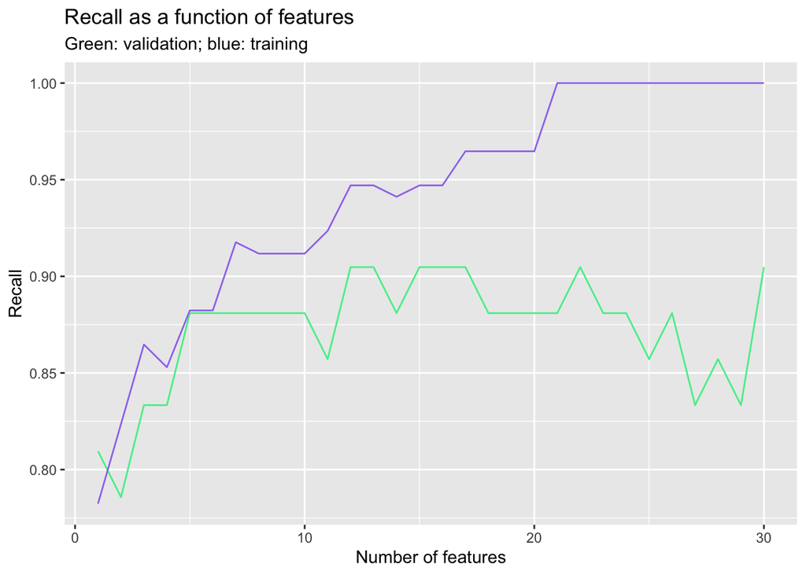

```r
data.frame(x = 1:30, Rv, Rt) %>% ggplot() +
geom_line(aes(x, Rv), col = "seagreen2") + geom_line(aes(x, Rt), col = "mediumpurple2") + labs(title = "Recall as a function of features",
        subtitle = "Green: validation; blue: training",
        x = "Number of features",
        y = "Recall")
```

### 4.3.3 Comment the results–what do you see?

The recall generally increase as features increase for training function and reach to 1 starting around 22.

The recall increase for validation function untill 5 keep constant from 5 - 10. The rate oscilate between 10 to 24, follow a slightly decrease and a rapid increase.

The result have overfitting concern since training data reach to 1